# Hello and welcome to **me, myself, and R**

by *cocoyamo

updated: 2024-06-06

## Introduction

**I have a toxic relationship with R Studio**

Hi, I am a student (not anymore very soon) who has been struggling with R Studio. Loving it and hating it (sometimes).

I use statistical analysis like t-tests, ANOVAs, and linear regressions often. I love to make graphs inside R Studio. Therefore I think it would be a great idea to post my journey here, mostly so that I won’t have to go to my past files and copy my codes whenever I want to do a new analysis.

Sometimes I use R Studio to do funny stuff, like drawing national flags, just for fun. So you will probably see those here.

Feel free to leave comments or suggestions, I am still an infant in the fascinating world of R, and am open to learn new things!

Best, *cocoyamo*

Reykjavik, 2024

## RStudio Environment and Installation

*first thing first: `install` and `library`*

I wish someone use this analogy when I was learning R Studio for the very first time.

People are constantly saying “oh you need to **install** this package”, and therefore I install every packages every time I am using R Studio.

Then people will ask you to “call the package out” using a function called `library`.

These two things inside R Studio confused me a lot in the beginning, (and I was mocked by a TA who was very inconsiderate of people who have never learned coding before), hopefully here you can find some answer. And I will not mock you. I swear. I know the struggles.

I now think of this as making a sandwich. Pick whatever sandwich you like. I will do a peanut butter and chocolate sandwich here.

So, imagine you are going to make peanut butter and chocolate sandwich. You need ingredients. So you went to a nearby grocery store to purchase *chocolate spread*, *peanut butter*, and *toast*. (Feel free to switch to any other food you like, also please do not follow my recipe if you are allergic to peanut or chocolate!)

This step (getting ingredients from a store) is called `install`.

Then, you go back to your kitchen, pull these ingredients out from your reusable bag, this action is similar to the `library` function.

Let’s assume these ingredients will never run out. (What a heaven!) Then, the next time you want the peanut butter and chocolate sandwich, all you need to do is to pull out these ingredients again. **There is no need to go back to the store every time you want it, you already have it in your kitchen!**

Therefore, whenever you need to use some package you have not used before, you need to `install` them first, and then afterwards, the only thing you need to do is to use the `library` function to pull these magical stuff out of your bag.

Okay, I hope you are still with me, and not already in the kitchen looking for your chocolate spread.

## Data Import and Reading

Let’s import our data!

### Import Your Data

**note: If this is your first time import data, and if your data is from an Excel file, then remember to type `install.packages("readxl")` on your coding space first.**

```r
install.packages("readxl")
```

```r
library(readxl)
```

There are of course tons of ways to import your data, but the following is what I use most often.

I will click `Import Dataset` on the top right corner in the `Environment` box. Then choose `import`, chose `From Excel` (or `From Text` if I have a .csv file), then use `Browse` on the top right corner to pick up the file I want to import.

You can either double-click or click it once and then click the `open` at the bottom right.

The middle part is the `Data Preview`, you can see your data here, don’t import the wrong file!(I’ve done that multiple times, especially when I am lazy at giving files proper names :P)

Then, you look at the bottom right corner, there is a section called `Code Preview`.

The code can look something like this. (But not identical! Because (hopefully) we are using different file names.)

```r
library(readxl)
wether_math <- read_excel("~/Documents/MMR/example files/wether_math.xlsx")
View(wether_math)
```

Now you have seen the `Code Preview` section, at the end of it there is a tiny icon looking like a clipboard, you do what? CLICK IT!

**Great Job!!**

Now you have copied the code necessary to import your file, press `Import` at the bottom right.

Go back to the coding section. Paste it (`Ctrl/Command + v`) on the coding section (the top left section of the interface).

(Let’s hope R Studio never change their interface or else I will have to rewrite this part.)

Also, sometimes you can use `head()` to see the first few rows of your data, just to make sure everything went well.

```r
head(wether_math)
```

```
## # A tibble: 6 × 3
##      id day   score
##   <dbl> <chr> <dbl>
## 1     1 sunny     9
## 2     2 sunny     8
## 3     3 sunny     7
## 4     4 sunny     8
## 5     5 sunny     8
## 6     6 sunny     8
```

Or you could just type in the data names.

```r
wether_math
```

```
## # A tibble: 20 × 3
##       id day   score
##    <dbl> <chr> <dbl>
##  1     1 sunny     9
##  2     2 sunny     8
##  3     3 sunny     7
##  4     4 sunny     8
##  5     5 sunny     8
##  6     6 sunny     8
##  7     7 sunny     6
##  8     8 sunny     5
##  9     9 sunny     3
## 10    10 sunny     4
## 11     1 rainy     1
## 12     2 rainy     3
## 13     3 rainy     5
## 14     4 rainy     7
## 15     5 rainy     6
## 16     6 rainy     5
## 17     7 rainy     6
## 18     8 rainy     7
## 19     9 rainy     5
## 20    10 rainy     3
```

#### Wether Math Data Explanation

Let us take a peek at this data, so you will have a better grasp in our future examples.

```r
wether_math
```

```
## # A tibble: 20 × 3
##       id day   score
##    <dbl> <chr> <dbl>
##  1     1 sunny     9
##  2     2 sunny     8
##  3     3 sunny     7
##  4     4 sunny     8
##  5     5 sunny     8
##  6     6 sunny     8
##  7     7 sunny     6
##  8     8 sunny     5
##  9     9 sunny     3
## 10    10 sunny     4
## 11     1 rainy     1
## 12     2 rainy     3
## 13     3 rainy     5
## 14     4 rainy     7
## 15     5 rainy     6
## 16     6 rainy     5
## 17     7 rainy     6
## 18     8 rainy     7
## 19     9 rainy     5
## 20    10 rainy     3
```

This is a made-up data. There are 10 imaginary people participate in this imaginary research. They do math test on both a rainy day and a sunny day. Their scores were recorded. Therefore, the first column is the participant number, the second column is the weather (either sunny or rainy), and the third column is their scores.

### Dataset packages

#### babynames

There are different data packages inside R. We can access those data by simply install them. For example, we can install a package called `babynames` .

This package contains baby names in the US from year 1880 to year 2017.

Let us take a look.

```r
install.packages("babynames")
```

```r
library(babynames)
babynames
```

```
## # A tibble: 1,924,665 × 5
##     year sex   name          n   prop
##    <dbl> <chr> <chr>     <int>  <dbl>
##  1  1880 F     Mary       7065 0.0724
##  2  1880 F     Anna       2604 0.0267
##  3  1880 F     Emma       2003 0.0205
##  4  1880 F     Elizabeth  1939 0.0199
##  5  1880 F     Minnie     1746 0.0179
##  6  1880 F     Margaret   1578 0.0162
##  7  1880 F     Ida        1472 0.0151
##  8  1880 F     Alice      1414 0.0145
##  9  1880 F     Bertha     1320 0.0135
## 10  1880 F     Sarah      1288 0.0132
## # ℹ 1,924,655 more rows
```

RStudio creates a separate page for the data when we use `View()` . We can see that there are 5 columns: `year`, `sex`, `name`, `n`, and `prop`.

Wait, what is the `prop`?

When we encounter questions like this, we can type `?+function/dataset` on the Console area. In this case, we typed `?babynames`.

Once we hit enter, we can see the Help screen on the right side popped up some information. After reading the explanation of this dataset, we learned that `prop` means `n` divided by all babies of that sex with that name born in that year.

#### starwars

There are also built-in data inside `dplyr` packages. For example, there is a dataset called `starwars`.

We can import them with a few lines of codes.

```r
install.packages("dplyr")
```

```r
library(dplyr)
```

We just called out the `dplyr` package, where `starwars` dataset was stored in.

```r
starwars
```

```
## # A tibble: 87 × 14
##    name     height  mass hair_color skin_color eye_color birth_year sex   gender
##    <chr>     <int> <dbl> <chr>      <chr>      <chr>          <dbl> <chr> <chr>
##  1 Luke Sk…    172    77 blond      fair       blue            19   male  mascu…
##  2 C-3PO       167    75 <NA>       gold       yellow         112   none  mascu…
##  3 R2-D2        96    32 <NA>       white, bl… red             33   none  mascu…
##  4 Darth V…    202   136 none       white      yellow          41.9 male  mascu…
##  5 Leia Or…    150    49 brown      light      brown           19   fema… femin…
##  6 Owen La…    178   120 brown, gr… light      blue            52   male  mascu…
##  7 Beru Wh…    165    75 brown      light      blue            47   fema… femin…
##  8 R5-D4        97    32 <NA>       white, red red             NA   none  mascu…
##  9 Biggs D…    183    84 black      light      brown           24   male  mascu…
## 10 Obi-Wan…    182    77 auburn, w… fair       blue-gray       57   male  mascu…
## # ℹ 77 more rows
## # ℹ 5 more variables: homeworld <chr>, species <chr>, films <list>,
## #   vehicles <list>, starships <list>
```

### Ways to Check Data

These functions are commonly used for checking data.

`View()` will open a new page for reading datasets.

`glimpse()` `head()` `tail()` `dim()` `slice()`

Also, you can check the qualities of datasets. For example, `ncol()` & `nrow()` . Both of them can be found at once when using `dim()`.

## Overview of Tidyverse and Core Functions

I really love tidyverse. It is a game changer. Three packages I use most often in tidyverse are:

1. `ggplot2`
2. `dplyr`
3. `tidyr`

But first we need to know what it is.

`Tidyverse` contains several packages, making data transformation and visualization (and my life) easier. Under the umbrella of `tidyverse`, we will be able to wrangle with data like a pro.

We will delve deeper into the land of `ggplot2` in the future chapter. Here, we focus on `dplyr` and `tidyr` first.

**If you have not use `tidyverse` before, you need to download the package first.**

```r
install.packages("tidyverse")
install.packages("dplyr")
install.packages("tidyr")
```

Next, let us not forget to also **call out** our packages, which we use `library()` function for the job.

```r
library("tidyverse")
library("dplyr")
library("tidyr")
```

You are all set.

Before we jump into anything, let us meet a funny-looking friend. *The pipe.*

It looks like this:

```r
%>%
```

In my humble opinion, this is one of the greatest analogy in this century. Although the way it looks (`%>%`) does not strike me as a real pipe at all.

Let us use an example to see how it works.

### babynames

`babynames` package is a built-in R package. It contains baby names in the US from year 1880 to year 2017.

We can take a look at the data.

```r
babynames
```

```
## # A tibble: 1,924,665 × 5
##     year sex   name          n   prop
##    <dbl> <chr> <chr>     <int>  <dbl>
##  1  1880 F     Mary       7065 0.0724
##  2  1880 F     Anna       2604 0.0267
##  3  1880 F     Emma       2003 0.0205
##  4  1880 F     Elizabeth  1939 0.0199
##  5  1880 F     Minnie     1746 0.0179
##  6  1880 F     Margaret   1578 0.0162
##  7  1880 F     Ida        1472 0.0151
##  8  1880 F     Alice      1414 0.0145
##  9  1880 F     Bertha     1320 0.0135
## 10  1880 F     Sarah      1288 0.0132
## # ℹ 1,924,655 more rows
```

RStudio should have created a separate page for the data. We can see that there are 5 columns: `year`, `sex`, `name`, `n`, and `prop`.

Wait, what are `prop`?

When we encounter questions like this, we can type `?+function/dataset` on the Console area. In this case, we typed `?babynames`.

Once we hit enter, we can see the Help screen on the right side popped up some information. After reading the explanation of this dataset, we learned that `prop` means `n` divided by all babies of that sex with that name born in that year.

Now, let’s say we want to know names of babies born in year 2000.

```r
babynames %>%
    filter(year == 2000)
```

```
## # A tibble: 29,769 × 5
##     year sex   name          n    prop
##    <dbl> <chr> <chr>     <int>   <dbl>
##  1  2000 F     Emily     25953 0.0130
##  2  2000 F     Hannah    23080 0.0116
##  3  2000 F     Madison   19967 0.0100
##  4  2000 F     Ashley    17997 0.00902
##  5  2000 F     Sarah     17697 0.00887
##  6  2000 F     Alexis    17629 0.00884
##  7  2000 F     Samantha  17266 0.00866
##  8  2000 F     Jessica   15709 0.00787
##  9  2000 F     Elizabeth 15094 0.00757
## 10  2000 F     Taylor    15078 0.00756
## # ℹ 29,759 more rows
```

Here we see all the baby names in 2000!

In the code, I used `%>%` to direct my dataset `babynames` into the next function `filter()`.

Inside the `filter()` function, I told the program I want babies who were born in year 2000. In other words, I filtered out the babies which in the ‘year’ column, says ‘2000’.

A good thing about the `%>%` is that you can build one after another. Just like you can direct the water from east to west, then from west to north.

Let’s try it out.

```r
babynames %>%
    filter(year == 2000) %>%
    filter(sex == "F")
```

```
## # A tibble: 17,653 × 5
##     year sex   name          n    prop
##    <dbl> <chr> <chr>     <int>   <dbl>
##  1  2000 F     Emily     25953 0.0130
##  2  2000 F     Hannah    23080 0.0116
##  3  2000 F     Madison   19967 0.0100
##  4  2000 F     Ashley    17997 0.00902
##  5  2000 F     Sarah     17697 0.00887
##  6  2000 F     Alexis    17629 0.00884
##  7  2000 F     Samantha  17266 0.00866
##  8  2000 F     Jessica   15709 0.00787
##  9  2000 F     Elizabeth 15094 0.00757
## 10  2000 F     Taylor    15078 0.00756
## # ℹ 17,643 more rows
```

Here we put F with a quotation mark because it is a character, instead of a number. We need to specify that so that RStudio can understands us.

Now the data is showing female babies who were both born in year 2000.

We can also acquire this output in another way.

```r
babynames %>%
 filter(year == 2000 & sex == "F")
```

```
## # A tibble: 17,653 × 5
##     year sex   name          n    prop
##    <dbl> <chr> <chr>     <int>   <dbl>
##  1  2000 F     Emily     25953 0.0130
##  2  2000 F     Hannah    23080 0.0116
##  3  2000 F     Madison   19967 0.0100
##  4  2000 F     Ashley    17997 0.00902
##  5  2000 F     Sarah     17697 0.00887
##  6  2000 F     Alexis    17629 0.00884
##  7  2000 F     Samantha  17266 0.00866
##  8  2000 F     Jessica   15709 0.00787
##  9  2000 F     Elizabeth 15094 0.00757
## 10  2000 F     Taylor    15078 0.00756
## # ℹ 17,643 more rows
```

Let us do more data transformation in the next chapter.

## Data Cleaning and Transformation

Here is a dataset for heros. I downloaded from https://github.com/dariomalchiodi/superhero-datascience/blob/master/content/data/heroes.csv?plain=1.

```r
library(readr)
setwd  ("~/Documents/MMR")
heroes <- read_delim("example files/heroes.csv",
    delim = ";", escape_double = FALSE, trim_ws = TRUE)
View(heroes)
```

Note that the spread sheet is in `.csv` form. Therefore, when we import data, we can choose `From Text(readr)` instead of `From Test(Excel)`.

However, we can see from the `Preview` to know that the data is not ideal as they only have one rows, with every information packed in each.

Here, we click on `Delimiter` and choose `Semicolon`. Telling RStudio that in this dataset, we separate different columns by `;` instead of comma or tab.

We can see from the data that it contains loads of heroes. If I want a neater view of data I needed the most, I can use `select()` to choose which columns I want to include for my further analysis.

```r
heroes |>
  select(c("Name", "Height", "Weight", "Gender", "Eye color", "Hair color", "Strength", "Intelligence"))
```

```
## # A tibble: 735 × 8
##    Name      Height Weight Gender `Eye color` `Hair color` Strength Intelligence
##    <chr>      <dbl>  <dbl> <chr>  <chr>       <chr>           <dbl> <chr>
##  1 A-Bomb      203.  442.  M      Yellow      No Hair           100 moderate
##  2 Abraxas      NA    NA   M      Blue        Black             100 high
##  3 Abominat…   203.  442.  M      Green       No Hair            80 good
##  4 Adam Mon…    NA    NA   M      Blue        Blond              10 good
##  5 Agent 13    173.   61.0 F      Blue        Blond              NA <NA>
##  6 Air-Walk…   189.  108.  M      Blue        White              85 average
##  7 Agent Bob   178.   81.4 M      Brown       Brown              10 low
##  8 Abe Sapi…   191.   65.4 M      Blue        No Hair            30 high
##  9 Abin Sur    186.   90.9 M      Blue        No Hair            90 average
## 10 Angela       NA    NA   F      <NA>        <NA>              100 high
## # ℹ 725 more rows
```

Now, if I want to choose heroes that have a high intelligence level, we can use `filter()`.

This function filters out the assigned rows.

```r
heroes |>
  filter(Intelligence == "high")
```

```
## # A tibble: 144 × 12
##    Name         Identity       `Birth place`      Publisher Height Weight Gender
##    <chr>        <chr>          <chr>              <chr>      <dbl>  <dbl> <chr>
##  1 Abraxas      Abraxas        Within Eternity    Marvel C…   NA     NA   M
##  2 Abe Sapien   Abraham Sapien <NA>               Dark Hor…  191.    65.4 M
##  3 Angela       <NA>           <NA>               Image Co…   NA     NA   F
##  4 Yoda         Yoda           <NA>               George L…   66.3   17.0 M
##  5 Zatanna      Zatanna Zatara <NA>               DC Comics  170.    57.8 F
##  6 Yellowjacket Hank Pym       Elmsford, New York Marvel C…  183.    83.7 M
##  7 X-Man        Nate Grey      American Northeas… Marvel C…  176.    61.8 M
##  8 Wonder Woman Diana Prince   Themyscira         DC Comics  183.    74.7 F
##  9 Watcher      Uatu           <NA>               Marvel C…   NA     NA   M
## 10 Warlock      Adam Warlock   The Beehive, Shar… Marvel C…  188.   108.  M
## # ℹ 134 more rows
## # ℹ 5 more variables: `First appearance` <dbl>, `Eye color` <chr>,
## #   `Hair color` <chr>, Strength <dbl>, Intelligence <chr>
```

The `select()` and `filter()` can be stacked together.

Let us look for heros who are female, has strength over 50, and have high intelligence level.

```r
heroes |>
  select(c("Name", "Gender", "Strength", "Intelligence")) |>
  filter(Gender == "F" & Strength >= 50 & Intelligence == "high")
```

```
## # A tibble: 18 × 4
##    Name            Gender Strength Intelligence
##    <chr>           <chr>     <dbl> <chr>
##  1 Angela          F           100 high
##  2 Wonder Woman    F           100 high
##  3 Valkyrie        F            95 high
##  4 Supergirl       F           100 high
##  5 Silk Spectre II F            55 high
##  6 She-Hulk        F           100 high
##  7 Power Girl      F           100 high
##  8 Phoenix         F           100 high
##  9 Lady Bullseye   F            75 high
## 10 Jean Grey       F            80 high
## 11 Granny Goodness F           100 high
## 12 Giganta         F            90 high
## 13 Faora           F            95 high
## 14 Donna Troy      F            95 high
## 15 Cheetah III     F           100 high
## 16 Cat             F            90 high
## 17 Captain Marvel  F            90 high
## 18 Big Barda       F           100 high
```

Next, if we want the same criteria except that we want both the intelligence `good` and `high`.

There are two ways of doing it. The first method is to use `|` as `or`. The second is method is to use `%in%`, meaning that if the data fits either of the option, then choose them.

```r
# method 1
heroes |>
  select(c("Name", "Gender", "Strength", "Intelligence")) |>
  filter(Gender == "F" & Strength >= 50) |>
  filter(Intelligence == "high" | Intelligence == "good")
```

```
## # A tibble: 47 × 4
##    Name         Gender Strength Intelligence
##    <chr>        <chr>     <dbl> <chr>
##  1 Angela       F           100 high
##  2 Wonder Girl  F            90 good
##  3 Wonder Woman F           100 high
##  4 Valkyrie     F            95 high
##  5 Vindicator   F            65 good
##  6 Thor Girl    F            85 good
##  7 T-X          F            65 good
##  8 Supergirl    F           100 high
##  9 Stargirl     F            80 good
## 10 Spider-Gwen  F            55 good
## # ℹ 37 more rows
```

```r
# method 2
heroes |>
  select(c("Name", "Gender", "Strength", "Intelligence")) |>
  filter(Gender == "F" & Strength >= 50) |>
  filter(Intelligence %in% c("high", "good"))
```

```
## # A tibble: 47 × 4
##    Name         Gender Strength Intelligence
##    <chr>        <chr>     <dbl> <chr>
##  1 Angela       F           100 high
##  2 Wonder Girl  F            90 good
##  3 Wonder Woman F           100 high
##  4 Valkyrie     F            95 high
##  5 Vindicator   F            65 good
##  6 Thor Girl    F            85 good
##  7 T-X          F            65 good
##  8 Supergirl    F           100 high
##  9 Stargirl     F            80 good
## 10 Spider-Gwen  F            55 good
## # ℹ 37 more rows
```

As we can see, both methods led to the same results. I would say the first one is more straight forward, however, I feel cooler when using the second method. :D

If we want to know the heroes’ BMI (body mass index), we can count the index by dividing their weights (in kilograms) by the square of their heights (in meters).

$$weight(kg)/(height*height(m))$$

According to this formula, we need to do the following things:

- add a new column that converts height from centimeters to meters
- calculate the square of the height in meters
- divide weight by the square of the heights

```r
heroes |>
  mutate(Height_m = Height / 100) |> # convert heights from cm to m
  mutate(Height_m2 = Height_m*Height_m) |> # square of the heights
  mutate(BMI = Weight / Height_m2) # divide weights by the squrare of the heights
```

```
## # A tibble: 735 × 15
##    Name        Identity             `Birth place` Publisher Height Weight Gender
##    <chr>       <chr>                <chr>         <chr>      <dbl>  <dbl> <chr>
##  1 A-Bomb      Richard Milhouse Jo… Scarsdale, A… Marvel C…   203.  442.  M
##  2 Abraxas     Abraxas              Within Etern… Marvel C…    NA    NA   M
##  3 Abomination Emil Blonsky         Zagreb, Yugo… Marvel C…   203.  442.  M
##  4 Adam Monroe <NA>                 <NA>          NBC - He…    NA    NA   M
##  5 Agent 13    Sharon Carter        <NA>          Marvel C…   173.   61.0 F
##  6 Air-Walker  Gabriel Lan          Xandar, a pl… Marvel C…   189.  108.  M
##  7 Agent Bob   Bob                  <NA>          Marvel C…   178.   81.4 M
##  8 Abe Sapien  Abraham Sapien       <NA>          Dark Hor…   191.   65.4 M
##  9 Abin Sur    <NA>                 Ungara        DC Comics   186.   90.9 M
## 10 Angela      <NA>                 <NA>          Image Co…    NA    NA   F
## # ℹ 725 more rows
## # ℹ 8 more variables: `First appearance` <dbl>, `Eye color` <chr>,
## #   `Hair color` <chr>, Strength <dbl>, Intelligence <chr>, Height_m <dbl>,
## #   Height_m2 <dbl>, BMI <dbl>
```

We can always simplified (or complicated, depending on your perspective) by mixing them into one line.

```r
heroes |>
  mutate(BMI = Weight / (Height/100)^2)
```

```
## # A tibble: 735 × 13
##    Name        Identity             `Birth place` Publisher Height Weight Gender
##    <chr>       <chr>                <chr>         <chr>      <dbl>  <dbl> <chr>
##  1 A-Bomb      Richard Milhouse Jo… Scarsdale, A… Marvel C…   203.  442.  M
##  2 Abraxas     Abraxas              Within Etern… Marvel C…    NA    NA   M
##  3 Abomination Emil Blonsky         Zagreb, Yugo… Marvel C…   203.  442.  M
##  4 Adam Monroe <NA>                 <NA>          NBC - He…    NA    NA   M
##  5 Agent 13    Sharon Carter        <NA>          Marvel C…   173.   61.0 F
##  6 Air-Walker  Gabriel Lan          Xandar, a pl… Marvel C…   189.  108.  M
##  7 Agent Bob   Bob                  <NA>          Marvel C…   178.   81.4 M
##  8 Abe Sapien  Abraham Sapien       <NA>          Dark Hor…   191.   65.4 M
##  9 Abin Sur    <NA>                 Ungara        DC Comics   186.   90.9 M
## 10 Angela      <NA>                 <NA>          Image Co…    NA    NA   F
## # ℹ 725 more rows
## # ℹ 6 more variables: `First appearance` <dbl>, `Eye color` <chr>,
## #   `Hair color` <chr>, Strength <dbl>, Intelligence <chr>, BMI <dbl>
```

The results will be the same with either one of the coding methods above. Choose what suits you the best.

There is a fun tip to put the new column on the left, instead of the right as default. The reason I like this method is that it helps me check the added column more easily, especially when there are lots of column. By doing so, I don’t have to go to the very end of the data to see my new added column.

```r
heroes |>
  mutate(BMI = Weight / (Height/100)^2, .before = 1)
```

```
## # A tibble: 735 × 13
##      BMI Name        Identity       `Birth place` Publisher Height Weight Gender
##    <dbl> <chr>       <chr>          <chr>         <chr>      <dbl>  <dbl> <chr>
##  1 107.  A-Bomb      Richard Milho… Scarsdale, A… Marvel C…   203.  442.  M
##  2  NA   Abraxas     Abraxas        Within Etern… Marvel C…    NA    NA   M
##  3 107.  Abomination Emil Blonsky   Zagreb, Yugo… Marvel C…   203.  442.  M
##  4  NA   Adam Monroe <NA>           <NA>          NBC - He…    NA    NA   M
##  5  20.3 Agent 13    Sharon Carter  <NA>          Marvel C…   173.   61.0 F
##  6  30.4 Air-Walker  Gabriel Lan    Xandar, a pl… Marvel C…   189.  108.  M
##  7  25.6 Agent Bob   Bob            <NA>          Marvel C…   178.   81.4 M
##  8  17.9 Abe Sapien  Abraham Sapien <NA>          Dark Hor…   191.   65.4 M
##  9  26.4 Abin Sur    <NA>           Ungara        DC Comics   186.   90.9 M
## 10  NA   Angela      <NA>           <NA>          Image Co…    NA    NA   F
## # ℹ 725 more rows
## # ℹ 5 more variables: `First appearance` <dbl>, `Eye color` <chr>,
## #   `Hair color` <chr>, Strength <dbl>, Intelligence <chr>
```

If I prefer the `Name` before `BMI`, I can use `.after = "Name" (column name)` to let RStudio know I want my new column be put on the right of the column I designated.

```r
heroes |>
  mutate(BMI = Weight / (Height/100)^2, .after = "Name")
```

```
## # A tibble: 735 × 13
##    Name          BMI Identity       `Birth place` Publisher Height Weight Gender
##    <chr>       <dbl> <chr>          <chr>         <chr>      <dbl>  <dbl> <chr>
##  1 A-Bomb      107.  Richard Milho… Scarsdale, A… Marvel C…   203.  442.  M
##  2 Abraxas      NA   Abraxas        Within Etern… Marvel C…    NA    NA   M
##  3 Abomination 107.  Emil Blonsky   Zagreb, Yugo… Marvel C…   203.  442.  M
##  4 Adam Monroe  NA   <NA>           <NA>          NBC - He…    NA    NA   M
##  5 Agent 13     20.3 Sharon Carter  <NA>          Marvel C…   173.   61.0 F
##  6 Air-Walker   30.4 Gabriel Lan    Xandar, a pl… Marvel C…   189.  108.  M
##  7 Agent Bob    25.6 Bob            <NA>          Marvel C…   178.   81.4 M
##  8 Abe Sapien   17.9 Abraham Sapien <NA>          Dark Hor…   191.   65.4 M
##  9 Abin Sur     26.4 <NA>           Ungara        DC Comics   186.   90.9 M
## 10 Angela       NA   <NA>           <NA>          Image Co…    NA    NA   F
## # ℹ 725 more rows
## # ℹ 5 more variables: `First appearance` <dbl>, `Eye color` <chr>,
## #   `Hair color` <chr>, Strength <dbl>, Intelligence <chr>
```

One last tip before we move on, if I want to only keep the columns we used during the `mutate()` process, instead of using `select()` and specify `BMI`, `Height`, and `Weight` columns, we can also use `.keep = "used"` to tell RStudio that we only want to keep those columns.

```r
heroes |>
  mutate(BMI = Weight / (Height/100)^2, .keep = "used")
```

```
## # A tibble: 735 × 3
##    Height Weight   BMI
##     <dbl>  <dbl> <dbl>
##  1   203.  442.  107.
##  2    NA    NA    NA
##  3   203.  442.  107.
##  4    NA    NA    NA
##  5   173.   61.0  20.3
##  6   189.  108.   30.4
##  7   178.   81.4  25.6
##  8   191.   65.4  17.9
##  9   186.   90.9  26.4
## 10    NA    NA    NA
## # ℹ 725 more rows
```

Now, what I experienced in elementary school, is that after the health examination each year, students would be categorized by their BMI. Then, homeroom teachers would tell those students who were categorized as “overweight”, “obese”, or “underweight” to be careful of their BMIs.

I am not going to discuss what kind of mental damage this caused me (as a child who often got the “overweight” label), but to use this as an example of how to categorize different numerical data into groups (categories) in RStudio.

According to Wikipedia, BMI can be simply categorized as following:

| BMI | Category |
| --- | --- |
| < 18.5 | underweight (UW) |
| 18.5 - 24.9 (inclusive) | normal weight (NW) |
| 25.0 - 29.9 (inclusive) | overweight (OW) |
| >= 30 | obese (OB) |

What we are going to do now, is to also categorize those heroes according to their BMIs.

We are still using `mutate()` since we are adding new columns containing their BMI status.

```r
heroes |>
  mutate(BMI = Weight / (Height/100)^2, .after = "Name") |>
  mutate(BMI_status = case_when(BMI < 18.5 ~ "underweight",
                                BMI >= 18.5 & BMI <= 24.9 ~ "normal_weight",
                                BMI >= 25 & BMI <= 29.9 ~ "overweight",
                                BMI >= 30 ~ "obese"), .after = "BMI") -> heroes2
```

```r
heroes2 |>
  count(BMI_status)
```

```
## # A tibble: 5 × 2
##   BMI_status        n
##   <chr>         <int>
## 1 normal_weight   201
## 2 obese           127
## 3 overweight      114
## 4 underweight      41
## 5 <NA>            252
```

Here, we can see how many heroes are obese.

We can also see that there is a row `<NA>`, it happens when the data is not complete. If we do not want those data with incomplete BMI information in our further analysis, we can remove the `<NA>` row by simply putting `na.omit()` into our codes. It would be easier to do further analysis as well.

```r
heroes2 |>
  na.omit() |>
  count(BMI_status)
```

```
## # A tibble: 4 × 2
##   BMI_status        n
##   <chr>         <int>
## 1 normal_weight    48
## 2 obese            40
## 3 overweight       40
## 4 underweight      13
```

We can also **update** our `heroes2` data with data with not omissions.

```r
heroes2 |>
  na.omit() -> heroes2
```

If we want further categorization, for instance, to know how many female and male heroes are obese or underweight, we can achieve it by adding another column into the `count()` function.

```r
heroes2 |>
  count(Gender, BMI_status)
```

```
## # A tibble: 8 × 3
##   Gender BMI_status        n
##   <chr>  <chr>         <int>
## 1 F      normal_weight    26
## 2 F      obese             1
## 3 F      overweight        1
## 4 F      underweight      12
## 5 M      normal_weight    22
## 6 M      obese            39
## 7 M      overweight       39
## 8 M      underweight       1
```

We can also use `group_by()` function, which will shortly be introduced in future chapters, to achieve the same result.

```r
heroes2 |>
  group_by(Gender) |>
  count(BMI_status)
```

```
## # A tibble: 8 × 3
## # Groups:   Gender [2]
##   Gender BMI_status        n
##   <chr>  <chr>         <int>
## 1 F      normal_weight    26
## 2 F      obese             1
## 3 F      overweight        1
## 4 F      underweight      12
## 5 M      normal_weight    22
## 6 M      obese            39
## 7 M      overweight       39
## 8 M      underweight       1
```

One last thing before moving on to the next chapter, is that we can actually change the column names in our data without going back to the `.csv` or `.xlsx` files!

Let’s say we want to change the column `Hair color` into `Hair_color`, and `Eye color` into `Eye_color`.

```r
colnames(heroes2)[colnames(heroes2) == "Hair color"] <- "Hair_color"
colnames(heroes2)[colnames(heroes2) == "Eye color"] <- "Eye_color"
```

## Data Wrangling and Reshaping

### pivot

This part is a bit abstract when I first learnt it. However, it was very useful when we have a **wide data** but need to do further analysis. RStudio prefers data being presented as a long format. For example:

| Name | Height (cm) | Age |
| --- | --- | --- |
| Lily | 150 | 20 |
| Mary | 160 | 18 |
| John | 156 | 14 |
| Steve | 180 | 15 |
| Amy | 174 | 16 |

The above table can go on and on, by adding new names below. However, sometimes we will encounter data that looks like this:

| Name | Eng_C1 | Eng_C2 | **Eng_C3** | Math_C1 | Math_C2 | Math_C3 |
| --- | --- | --- | --- | --- | --- | --- |
| Kelly | 90 | 95 | 80 | 90 | 80 | 97 |
| Liam | 70 | 80 | 94 | 80 | 89 | 79 |
| Henry | 79 | 80 | 85 | 96 | 92 | 90 |

This is a made-up data displaying different students’ exam performance. They took exams on both English and Math, from Chapter 1 (C1) to Chapter 3 (C3).

In these cases, it is better to convert our **wide** data into **long** data. As we move along, we will start doing analysis (t-tests, ANOVAs…), when we are doing the analysis, it would be easier if we could assign **rows** as variables. For example, in the above table, I would want the *subject* (English or Math) to be one independent variable, and their *scores* as dependent variable.

Let us create the data first.

```r
performance_original <- data.frame(
   Name = c("Kelly", "Liam", "Henry", "Alice", "Jake", "Dan"),
   Eng_C1 = c(90, 70, 79, 98, 81, 79),
   Eng_C2 = c(95, 80, 80, 93, 93, 70),
   Eng_C3 = c(80, 94, 85, 89, 73, 91),
   Math_C1 = c(90, 80, 96, 83, 92, 68),
   Math_C2 = c(80, 89, 92, 72, 84, 83),
   Math_C3 = c(97, 79, 90, 74, 70, 92))
```

We want to make the data look somewhat like this:

| Name | Subject | Score |
| --- | --- | --- |
| Kelly | Eng_C1 | 90 |
| Kelly | Eng_C2 | 95 |
| Kelly | Eng_C3 | 80 |
| Kelly | Math_C1 | 90 |
| Kelly | Math_C2 | 80 |
| Kelly | Math_C3 | 97 |
| Liam | Eng_C1 | 70 |
| Liam | Eng_C2 | 80 |
| Liam | Eng_C3 | 94 |
| Liam | Math_C1 | 80 |
| Liam | Math_C2 | 89 |
| Liam | Math_C3 | 79 |
| Henry | Eng_C1 | 79 |
| Henry | Eng_C2 | 80 |
| … and so on |  |  |

Here, we will use `pivot_longer()` to help us.

```r
performance_original |>
  pivot_longer(!Name, names_to = "Subject", values_to = "Score")
```

```
## # A tibble: 36 × 3
##    Name  Subject Score
##    <chr> <chr>   <dbl>
##  1 Kelly Eng_C1     90
##  2 Kelly Eng_C2     95
##  3 Kelly Eng_C3     80
##  4 Kelly Math_C1    90
##  5 Kelly Math_C2    80
##  6 Kelly Math_C3    97
##  7 Liam  Eng_C1     70
##  8 Liam  Eng_C2     80
##  9 Liam  Eng_C3     94
## 10 Liam  Math_C1    80
## # ℹ 26 more rows
```

We can see that the data format became what we wanted. Let us see what are inside the code chunks. `!Name` means that I am asking RStudio to not consider the column `Name` as we still want the dataset contain students’ names.

Right after the `!Name`, we see the code `names_to =`. When we are compressing multiple columns into one (like we are doing right now), the name of the new column can be specify by `names_to =`. On this basis, when we look at `values_to =`, we can infer that it means putting the numerical data into this new column.

However, there are other ways to accomplish the same result. It works when the original column numbers are not huge, or when you have too many columns to exclude than just names.

```r
performance_original |>
  pivot_longer(cols = c("Eng_C1", "Eng_C2", "Eng_C3", "Math_C1", "Math_C2", "Math_C3"),
               names_to = "Subject", values_to = "Score") -> performance
```

Here, we use `cols =` to select the columns we want to compress. However, in this example, it would be easier to use `!Names` instead of using `cols =` and type out all columns that needed compressing.

Now, bear with me when this gets even more abstract.

If we want to **further separate** our data by chapters. For instance, we want to further separate `Subject` columns to `Subject_em` AND `Chapter`. In this case, we need to use `separate()` function.

```r
performance |>
  separate(
    col = Subject,
    into = c("Subject_em", "Chapter"),
    sep = "[^[:alnum:]]+",
    remove = TRUE,
    convert = FALSE) -> performance
```

I know it looks scary, but please hear me out. This would be one of your best friends if you try to understand it. :)

As we mentioned, we want to further separate our `Subject` column into `Subject_em` and `Chapter`. Hence, we use `col =` to specify which column is our target. Then, we use `into =` to tell RStudio that we want to separate the column above to columns with these names.

Then, we saw a bizarre-looking code `sep = "[^[:alnum:]]+"`. We need to separate this line to understand it. In general, it means **“one or more non-alphabet or non-numeric characters”**.

- `[:alnum:]` means the **al**phabet A-Z (a-z), and **num**ber 0-9.
- `[^]` means **not include**.
- `+` means **one or more**.

When we combine the above segments together, means that we want **one or more *things*** **that are *not* alphabet nor number**. In this case, we just want to fine the character `_`, and let RStudio knows that this `_` is the separation point.

Moving on, we see `remove = TRUE` and `convert = FALSE`. Both of them are defaults in this `separate()` function. We do not have to type it. However, I want to put it here to remind myself.

- `remove = TRUE` means to delete the original column `Subject` in this case.
- `convert = FALSE` means that we do not want RStudio to change the types of columns for us. Sometimes after the separation, there would be columns with numerical data (for instance, separate `Eng_1` into `Eng` and `1`), if we choose `convert = TRUE`, then the column would be automatically changed into numeric. However, we can change the column type later on if we want to. We don’t need RStudio to do that for us in this step. Thus, we keep this argument `FALSE`.

Congratulations! Now we learned how to pivot our wide format data into long format data, and we learned how to separate columns. (After 5 years of learning and using RStuido, I am still stunned by its power. EVERY SINGLE TIME.)

If we have `pivot_longer()`, there must be a `pivot_wider()`. As a matter of fact it did! However, like I said, RStudio prefers data with a long format for further analysis and graphing, therefore, I will only mention `pivot_longer()` here, as in my opinion it is more useful for data analysis and data visualization. (Or I will add it when I am more proficient with `pivot_wider()` function haha).

### join

This is another useful function when we have multiple datasets/files and we want to combine them into one dataset.

Here, we are going to continue using the `performance` dataset. Let’s say that we also documented their Biology exams in another file.

```r
performance_biology <- data.frame(
   Name = c("Kelly", "Liam", "Henry", "Alice", "Jake", "Dan"),
   Bio_C1 = c(80, 80, 83, 93, 80, 88),
   Bio_C2 = c(73, 76, 75, 77, 79, 83),
   Bio_C3 = c(90, 93, 94, 90, 81, 82))
```

We pull out the original performance data, and want to add these biology columns on it.

```r
performance_original |>
  left_join(performance_biology, by = "Name")
```

```
##    Name Eng_C1 Eng_C2 Eng_C3 Math_C1 Math_C2 Math_C3 Bio_C1 Bio_C2 Bio_C3
## 1 Kelly     90     95     80      90      80      97     80     73     90
## 2  Liam     70     80     94      80      89      79     80     76     93
## 3 Henry     79     80     85      96      92      90     83     75     94
## 4 Alice     98     93     89      83      72      74     93     77     90
## 5  Jake     81     93     73      92      84      70     80     79     81
## 6   Dan     79     70     91      68      83      92     88     83     82
```

Here, we can see that we have successfully added the biology columns on the original dataset. Of course, when we have multiple independent variables (columns), we can use `by = c("column1", "column2", …)` to specify the left join basis.

Yes. You guess right. There is also a `right_join()` in RStudio. Although it may not be as often used as the `left_join()` (in my usual data analysis), I still sometimes use it. So let us look at the differences between `left_join()` and `right_join()`.

`left_join()`: keeps data on the left, even if there is no matching data on the right.

`right_join()`: keeps data on the right, even if there is no matching data on the left.

If they encountered missing data, they will put an `NA` on it. It is as simple as that but still extremely powerful (and magical).

### bind

Except for left and right join, there is another way to combine different datasets into one.

```r
dataset1 <- data.frame(
  brand = c("1","2","3"),
  price = c(200, 300, 250),
  profit = c(100, 200, 200))
dataset2 <- data.frame(
  brand = c("1","2","3"),
  sales = c(20, 40, 60))
```

We have created two separate datassets. One contains a product’s brand, price, and profit. The other contains the sales number.

```r
cbind(dataset1, dataset2) -> merged_data
merged_data
```

```
##   brand price profit brand sales
## 1     1   200    100     1    20
## 2     2   300    200     2    40
## 3     3   250    200     3    60
```

Through `cbind` (column bind), we can merge two datassets.

However, we can also see that it repeated the column `brand` into the merged data. If this does not affect your future analysis, then you could leave it. Or you could simply use `left_join()` (as mentioned above) to do the binding without creating the extra column.

```r
dataset1 |>
  left_join(dataset2, by = "brand")
```

```
##   brand price profit sales
## 1     1   200    100    20
## 2     2   300    200    40
## 3     3   250    200    60
```

## Statistical Analysis

### t-test

Let us look at the strength difference from different publishers.

```r
heroes2 |>
  group_by(Publisher) |>
  summarize(mean_strength = mean(Strength, na.rm = TRUE))
```

```
## # A tibble: 4 × 2
##   Publisher     mean_strength
##   <chr>                 <dbl>
## 1 DC Comics              64.6
## 2 George Lucas           33.3
## 3 Image Comics           60
## 4 Marvel Comics          43.1
```

We can see from the result that the mean strength of difference publishers are different. However, is the difference significant?

Let us look at DC Comics vs Marvel Comics.

```r
heroes2 |>
  filter(Publisher %in% c("Marvel Comics", "DC Comics")) |>
  group_by(Publisher) |>
  summarize(Strengths = list(Strength)) |>
  with(t.test(Strengths[[1]], Strengths[[2]], paired = FALSE))
```

```
##
##  Welch Two Sample t-test
##
## data:  Strengths[[1]] and Strengths[[2]]
## t = 2.8807, df = 32.441, p-value = 0.00698
## alternative hypothesis: true difference in means is not equal to 0
## 95 percent confidence interval:
##   6.297946 36.652054
## sample estimates:
## mean of x mean of y
##    64.600    43.125
```

That looks complicated. I do not normally use that.

I first `subset` different groups of data.

```r
subset(heroes2, Publisher == "Marvel Comics") -> marvel
subset(heroes2, Publisher == "DC Comics") -> DC
```

Then, I calculate the difference between these two groups of data using `t.test()`.

```r
heroes2 |>
  with(t.test(marvel$Strength, DC$Strength, paired = F))
```

```
##
##  Welch Two Sample t-test
##
## data:  marvel$Strength and DC$Strength
## t = -2.8807, df = 32.441, p-value = 0.00698
## alternative hypothesis: true difference in means is not equal to 0
## 95 percent confidence interval:
##  -36.652054  -6.297946
## sample estimates:
## mean of x mean of y
##    43.125    64.600
```

Here, because the heroes from DC universe are different from the heroes from Marvel universe. Thus, we cannot use `pairwise` t-test.

However, when we are calculate a same group of people doing different tasks (or doing same task repeatedly), then we can use `pairwise` t-test.

I hope you still remember the performance data. Let us say we want to look at if there is any difference between exam scores of Chapter 1 and Chapter 3.

```r
# group them first
subset(performance, Subject_em == "Eng" & Chapter == "C1") -> eng_c1
subset(performance, Subject_em == "Eng" & Chapter == "C3") -> eng_c3

performance |>
  with(t.test(eng_c1$Score, eng_c3$Score, paired = T))
```

```
##
##  Paired t-test
##
## data:  eng_c1$Score and eng_c3$Score
## t = -0.44114, df = 5, p-value = 0.6775
## alternative hypothesis: true mean difference is not equal to 0
## 95 percent confidence interval:
##  -17.06789  12.06789
## sample estimates:
## mean difference
##            -2.5
```

### ANOVA

Here is a template for `anova_test()`.

```r
library(rstatix)
```

```r
heroes2 |>
  anova_test(
    dv = # dependent variable,
    wid = # subject name/id,
    type = NULL, # default: type II ANOVA
    between = # between-subject independent variable,
    within = # within-subject independent variable,
    effect.size = "ges",
    error = NULL,
    white.adjust = FALSE,
    observed = NULL,
    detailed = TRUE
  )
```

- `detailed = F` is the default. However, I would like my results a bit more informative. Thus, I would normally change it to `detailed = T`.
- `type = NULL` is the default. It uses type 2 ANOVA. When needed to change, just switch it from `NULL` to `1` or `3`.
- You can add `covariate =` below `within =`, above `type =` , for ANCOVA.
- `effect.size =` is the effect size to compute.
  - `pes` (partial eta squared)
  - `ges` (generalized eta squared) **Default**
  - The `Help` section in RStudio says I could choose both, but I haven’t figure out how to do so yet.

#### one-way ANOVA

##### example 1: strength ~ intelligence

IV: intelligence

DV: strength

```r
heroes2 |>
  anova_test(
    dv = Strength,
    wid = Name,
    between = Intelligence,
    detailed = T
  )
```

```
## ANOVA Table (type II tests)
##
##         Effect      SSn    SSd DFn DFd     F     p p<.05   ges
## 1 Intelligence 8758.544 129262   4 136 2.304 0.062       0.063
```

##### example 2: strength ~ gender

IV: gender

DV: strength

```r
heroes2 |>
  anova_test(
    dv = Strength,
    wid = Name,
    between = Gender,
    detailed = T
  )
```

```
## ANOVA Table (type II tests)
##
##   Effect      SSn      SSd DFn DFd     F    p p<.05   ges
## 1 Gender 3772.182 134248.4   1 139 3.906 0.05       0.027
```

#### two-way ANOVA

##### example 1: strength ~ BMI_status * gender

```r
heroes2 |>
   anova_test(
    dv = Strength,
    wid = Name,
    between = c(Gender, BMI_status),
    detailed = TRUE
  )
```

```
## ANOVA Table (type III tests)
##
##              Effect       SSn      SSd DFn DFd      F        p p<.05      ges
## 1       (Intercept) 68473.044 109803.3   1 133 82.938 1.11e-15     * 0.384000
## 2            Gender    51.278 109803.3   1 133  0.062 8.04e-01       0.000467
## 3        BMI_status  8413.707 109803.3   3 133  3.397 2.00e-02     * 0.071000
## 4 Gender:BMI_status  6885.839 109803.3   3 133  2.780 4.40e-02     * 0.059000
```

Careful of the ANOVA type. Even if I did not specify which types of ANOVA I want to use, the system chose `type III` for me. Add `type = 2` if you would like to stick with `type II` ANOVA.

##### example 2: strength ~ gender * BMI

```r
heroes2 |>
  anova_test(
    dv = Strength,
    wid = Name,
    between = c(Gender, BMI),
    detailed = T
  )
```

However, we would encounter an error here. Why is that?

*Step 1*

We examine if the two independent variables are in different types. For example, **categories** and **numerical** variables. This would happen if we put `Gender` (category) and `BMI` (numbers) in the `between =` section.  
Solutions: 1. change the numerical columns into categorical column. For example, categorize BMI into different levels like obese, overweight, normal, and underweight. (We did this in the previous section, so I am just going to put the end code here). 2. use ANCOVA (continuous * category ~ continuous) instead of ANOVA. Simply put the numerical variables in the `covariate =` section. I will not go further on this topic here as we are in the `ANOVA` section, and as I am not familiar with ANCOVA. Will come back when I use it more often.

```r
# solution 1
heroes2 |>
   anova_test(
    dv = Strength,
    wid = Name,
    between = c(Gender, BMI_status),
    detailed = T
  )
```

```
## ANOVA Table (type III tests)
##
##              Effect       SSn      SSd DFn DFd      F        p p<.05      ges
## 1       (Intercept) 68473.044 109803.3   1 133 82.938 1.11e-15     * 0.384000
## 2            Gender    51.278 109803.3   1 133  0.062 8.04e-01       0.000467
## 3        BMI_status  8413.707 109803.3   3 133  3.397 2.00e-02     * 0.071000
## 4 Gender:BMI_status  6885.839 109803.3   3 133  2.780 4.40e-02     * 0.059000
```

```r
# solution 2 (ANCOVA)
heroes2 |>
   anova_test(
    dv = Strength,
    wid = Name,
    between = Gender,
    covariate = BMI,
    detailed = T
  )
```

```
## ANOVA Table (type II tests)
##
##   Effect       SSn      SSd DFn DFd      F        p p<.05      ges
## 1    BMI 23336.275 110912.1   1 138 29.036 2.99e-07     * 1.74e-01
## 2 Gender    10.606 110912.1   1 138  0.013 9.09e-01       9.56e-05
```

##### example 3: strength ~ gender * Intelligence

Let us take a look at another example.

We know in the `heroes2` data, the `Intelligence` is a **categorical variable**. Heroes’ intelligence levels is labelled as `high`, `good`, `average`, `moderate`, and `low`.

```r
heroes2 |>
  distinct(Intelligence)
```

```
## # A tibble: 5 × 1
##   Intelligence
##   <chr>
## 1 moderate
## 2 good
## 3 high
## 4 average
## 5 low
```

Therefore, it should not encounter the same problem as example 2.

```r
heroes2 |>
  anova_test(
    dv = Strength,
    wid = Name,
    between = c(Gender, Intelligence),
    detailed = T)
```

However, we still see errors here. If we finished examining that the *Step 1* is not the issue here. We can try to debug using the following ways.

*Step 2*

We examine both independent variables separately to make sure they are both working fine individually. Just delete one of the variables each time to make sure. (Usually this is not the problem, but just in case, I would still check it)

- checking variable `Gender`

```r
heroes2 |>
  anova_test(
    dv = Strength,
    wid = Name,
    between = Gender,
    detailed = T)
```

```
## ANOVA Table (type II tests)
##
##   Effect      SSn      SSd DFn DFd     F    p p<.05   ges
## 1 Gender 3772.182 134248.4   1 139 3.906 0.05       0.027
```

- checking variable `Intelligence`

```r
heroes2 |>
  anova_test(
    dv = Strength,
    wid = Name,
    between = Intelligence,
    detailed = T)
```

```
## ANOVA Table (type II tests)
##
##         Effect      SSn    SSd DFn DFd     F     p p<.05   ges
## 1 Intelligence 8758.544 129262   4 136 2.304 0.062       0.063
```

Both variables look fine and the code work smoothly individually.

*Step 3*

We examine if there are any **missing values** in any of the category. (I often forgot about this step, and got confused on how my ANOVA did not work for hours…)

```r
table(heroes2$Gender, heroes2$Intelligence)
```

```
##
##     average good high low moderate
##   F      14   20    4   0        2
##   M      24   41   27   2        7
```

Here, we can see that in female heroes, low intelligence level, there is a zero. This would make the ANOVA unable to proceed. Now we found the problem, we could simply remove the `intelligence == "low"` from our analysis as it hinders it.

```r
heroes2 |>
  filter(Intelligence != "low") |>
   anova_test(
    dv = Strength,
    wid = Name,
    between = c(Gender, Intelligence),
    type = 2,
    detailed = T)
```

```
## ANOVA Table (type II tests)
##
##                Effect      SSn      SSd DFn DFd     F     p p<.05   ges
## 1              Gender 1982.076 126823.2   1 131 2.047 0.155       0.015
## 2        Intelligence 3719.933 126823.2   3 131 1.281 0.284       0.028
## 3 Gender:Intelligence  406.757 126823.2   3 131 0.140 0.936       0.003
```

Maybe you would think: I’ll just add `group_by()` before the `anova_test()`. However, while this would work, it would not be **two-way ANOVA** as we wanted. Instead, it would just separate the data into two groups before performing **one-way ANOVA** on each. See the codes below:

```r
heroes2 |>
  filter(Intelligence != "low") |>
  group_by(Gender) |>
   anova_test(
    dv = Strength,
    wid = Name,
    between = Intelligence,
    detailed = T
  )
```

```
## # A tibble: 2 × 10
##   Gender Effect         SSn    SSd   DFn   DFd     F     p `p<.05`   ges
## * <chr>  <chr>        <dbl>  <dbl> <dbl> <dbl> <dbl> <dbl> <chr>   <dbl>
## 1 F      Intelligence 1564. 33535.     3    36  0.56 0.645 ""      0.045
## 2 M      Intelligence 2563. 93288.     3    95  0.87 0.46  ""      0.027
```

We can see the result table is different from the two-way ANOVA table (refer to the upper table), as well as the numbers are different. (See `DFn` and `DFd` in both results.)

#### three-way ANOVA

If we want to add more independent variables, we could just add more column names in the `between =` section.

```r
heroes2 |>
  filter(Intelligence != "low") |>
   anova_test(
    dv = Strength,
    wid = Name,
    between = c(Gender, Intelligence, BMI_status),
    type = 2,
    detailed = T
  )
```

```
## ANOVA Table (type II tests)
##
##                           Effect       SSn      SSd DFn DFd     F        p
## 1                         Gender  1083.194 96626.99   1 118 1.323 0.252000
## 2                   Intelligence  3465.586 96626.99   3 118 1.411 0.243000
## 3                     BMI_status 16524.941 96626.99   3 118 6.727 0.000314
## 4            Gender:Intelligence  2703.193 96626.99   2 118 1.651 0.196000
## 5              Gender:BMI_status  8295.111 96626.99   3 118 3.377 0.021000
## 6        Intelligence:BMI_status  7715.048 96626.99   7 118 1.346 0.235000
## 7 Gender:Intelligence:BMI_status        NA 96626.99   0 118    NA       NA
##   p<.05   ges
## 1       0.011
## 2       0.035
## 3     * 0.146
## 4       0.027
## 5     * 0.079
## 6       0.074
## 7  <NA>    NA
```

Note that if the independent variable is within subject (if this is an mixed analysis), then we put the independent variables that is **within subject** in the `within =` section. This is often used when analyze experiment results and want to analyze for example the test score before learning and after learning. See below to know more about the mixed ANOVA.

#### mixed ANOVA

As mentioned, mixed ANOVA is more often used in analyze experiment results as it would be difficult to obtain individual changes over time with other methods.

Let us assume a high school is trying to know if different teaching styles affect students’ exam scores. They performed experiments on students, separating them into two groups, one group received education in a fun way, the other in a rigid way. The school also performed exams before they learn the subject and after learning.

- Independent variable: teaching style (fun/rigid), exam time (before/after)
- Dependent variable: exam score

```r
teaching_style <- data.frame(
  student = c("1", "2", "3", "4", "5", "6",
              "1", "2", "3", "4", "5", "6"),
  style = as.factor(c("fun", "rigid", "fun", "rigid", "fun", "rigid",
                      "fun", "rigid", "fun", "rigid", "fun", "rigid")),
  timing = as.factor(c("before", "before", "before", "before", "before", "before",
                       "after", "after", "after", "after", "after", "after")),
  score = c(50, 13, 10, 70, 23, 70, 70, 90, 66, 83, 80, 80)
  )
```

The data frame is created. There are 6 students in total. 3 attended the `fun` style teaching, 3 experienced the `rigid` style. All of their `before` and `after` exam scores are also presented.

Here, we want to see if the teaching style made differences on their score.

```r
teaching_style |>
   anova_test(
    dv = score,
    wid = student,
    between = style,
    within = timing,
    detailed = T)
```

```
## ANOVA Table (type II tests)
##
##         Effect DFn DFd       SSn      SSd       F       p p<.05   ges
## 1  (Intercept)   1   4 41418.750 1278.667 129.569 0.00034     * 0.929
## 2        style   1   4   954.083 1278.667   2.985 0.15900       0.232
## 3       timing   1   4  4524.083 1876.667   9.643 0.03600     * 0.589
## 4 style:timing   1   4    90.750 1876.667   0.193 0.68300       0.028
```

By the analysis, we can see that the style does not have a significant impact on their scores. However, we can see that there is a main effect on `timing` variable.

We can through looking into the means of the score of different timing to know that the students perform better after learning, no matter what kinds of learning style was implemented on them.

```r
teaching_style |>
  group_by(timing) |>
  summarise(mean_score = mean(score))
```

```
## # A tibble: 2 × 2
##   timing mean_score
##   <fct>       <dbl>
## 1 after        78.2
## 2 before       39.3
```

**Additional notes**

- add `filter()` to choose specific groups you wanted in your analysis. For instance, `filter(Intelligence %in% c("high", "good")` or `filter(Hair_color != "No Hair")`
- `group_by()` could still come in handy when you want to see both conditions’ ANOVA result.

### Post hoc analysis

After ANOVA, if we want to dig deeper into the data (and if the ANOVA has significant result), we can use post hoc analysis.

I used to get confused regarding post hoc analysis and pairwise t test. Note that post hoc analysis comes **after** we retrieved a significant result from ANOVA, while pairwise t-test can be implemented on whatever two groups of data.

```r
teaching_style |>
 group_by(style) |>
  pairwise_t_test(
    score ~ timing,
    paired = TRUE,
    p.adjust.method = "bonferroni"
  )
```

```
## # A tibble: 2 × 11
##   style .y.   group1 group2    n1    n2 statistic    df     p p.adj p.adj.signif
## * <fct> <chr> <chr>  <chr>  <int> <int>     <dbl> <dbl> <dbl> <dbl> <chr>
## 1 fun   score after  before     3     3      3.64     2 0.068 0.068 ns
## 2 rigid score after  before     3     3      1.53     2 0.267 0.267 ns
```

Here, we use post hoc analysis

- `score ~ timing`: we put the **dependent variable** on the left, the **independent variable** on the right. Here, we compare the `scores` under different exam `timing`.
- `paired =` if it was repeated measures, then `TRUE`, if not (implemented on different participants, aka between-subject), then `FALSE`.
- `p.adjust.method`: allows us to choose the method for adjusting p values.

### Regression analysis

## Data Visualization

### bar chart

We took the `heroes` dataset as an example again.

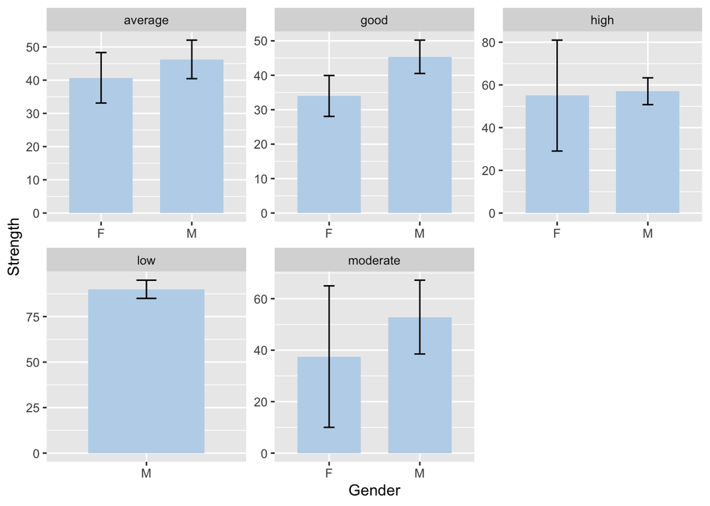

```r
heroes2 |>
  ggplot(aes(x = Gender, y = Strength)) +
  geom_bar(stat = "summary", position = position_dodge(.8), width = .7, fill = "#BDD5EA") +
  geom_errorbar(stat = "summary", position = position_dodge(0.5), width = .12) +
  facet_wrap(Intelligence ~ ., scales = "free")
```

Looks like a lot had happened during in the code chunk, also a lot of information from the graphs.

Let us start with the code.

- in `ggplot()`, we specify the `x` axis and `y` axis.
- `geom_bar()` creates bar chart.
  - `stat = "summary"` helps you calculate the mean value of the y-axis, `Strength` in this case.
  - `position = position_dodge()`
  - `width =` is the width of the bar. When the `width = 1`, the bars would stick together.
  - `fill =` can either be a single color (like in this example), or could be other variables.
- `geom_errorbar()` helps calculate the standard error of the value, then presented it on the graph.
  - the `width`, `fill`, `position` remain the same functions as in `geom_bar()`
- `facet_wrap()` helps you to separate graphs according to the variable you put in.
  - You can either do `<your variable> ~.` or `~ <your variable>`.
  - The `scales = "free"` helps change the y-axis of each graph according to their maximum values. It is however not recommended in some situations, we will explain below.

Then, let’s take a look at the graph. We can see a few things:

1. The graphs were separated by different intelligence levels.
2. In the **low** intelligence group, there is only male heroes’ strength data. Indicating there is no female heroes in the low intelligence group.
3. The y-axis scale is different from one graph to another. Although it is good that the program changes the scale according to our data, it might hinder some vital information. For example, in the `good` intelligence group and the `high` intelligence group, their average strength are calculated below:

```r
heroes2 |>
  filter(Intelligence %in% c("good", "high")) |>
  group_by(Intelligence, Gender) |>
  summarise(mean_strength = mean(Strength))
```

```
## # A tibble: 4 × 3
## # Groups:   Intelligence [2]
##   Intelligence Gender mean_strength
##   <chr>        <chr>          <dbl>
## 1 good         F               34
## 2 good         M               45.4
## 3 high         F               55
## 4 high         M               57.0
```

We can see from the result that in the `good` intelligence group, the mean strength of both genders are lower than the `high` intelligence group. However, in the graph, if we did not pay attention to the y-axis at first, we might get an wrong impression of the `good` intelligence group has higher strength than the `high` intelligence group.

If we want to resolve this issue, we can manually change the scale by using `coord_cartesian()`. We can either remove the `scales = "free"` or leave it there. Since the code was implemented layer by layer, when we added the manual scale after `scales = "free"`, then the graph would not be affected.

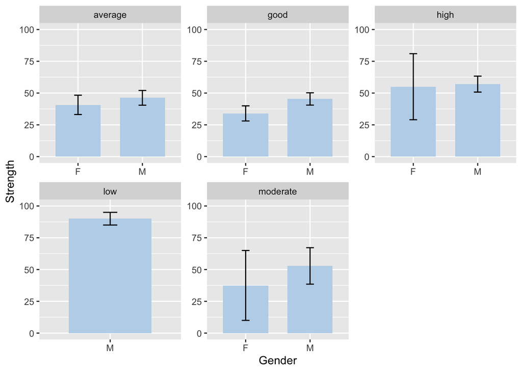

```r
heroes2 |>
  ggplot(aes(x = Gender, y = Strength)) +
  geom_bar(stat = "summary", position = position_dodge(.8), width = .7, fill = "#BDD5EA") +
  geom_errorbar(stat = "summary", position = position_dodge(0.5), width = .12) +
  facet_wrap(Intelligence ~ ., scales = "free") +
  coord_cartesian(ylim = c(0,100))
```

After putting each graph on the same scale, it would be a lot easier to look into the relationships between graphs.

> In the bar chart section alone, we learned two new functions: `facet_wrap()` and `coord_cartesian()`. Keep these in mind because they really come in handy when doing data visualization.

### scatter plot

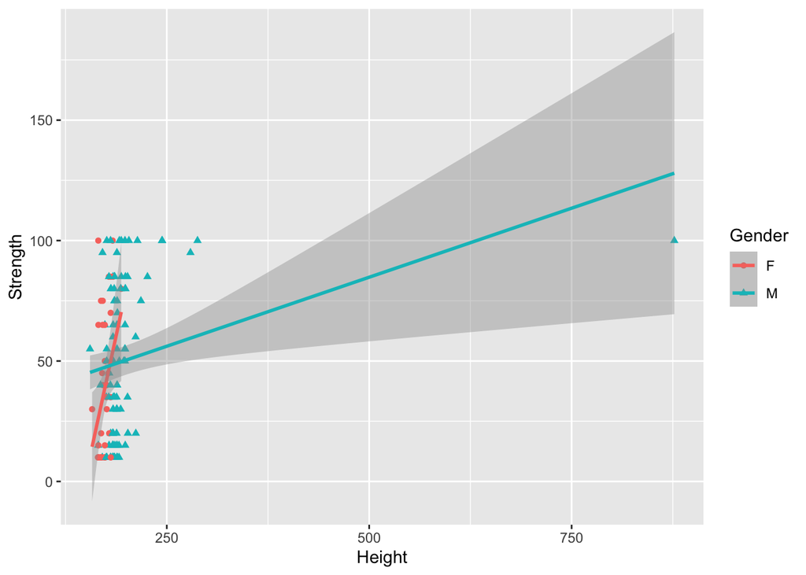

```r
heroes2 |>
  ggplot(aes(x = Height, y = Strength, color = Gender, shape = Gender)) +
  geom_point() +
  geom_smooth(method = "lm")
```

We can see from the plot that this is probably not the best data to demonstrate scatter plot when the outliers are obviously affecting the aesthetics. Let us try to move out that male hero on the very right side of the graph. Since we are removing the hero (row), therefore we need to use `filter()` to help us out.

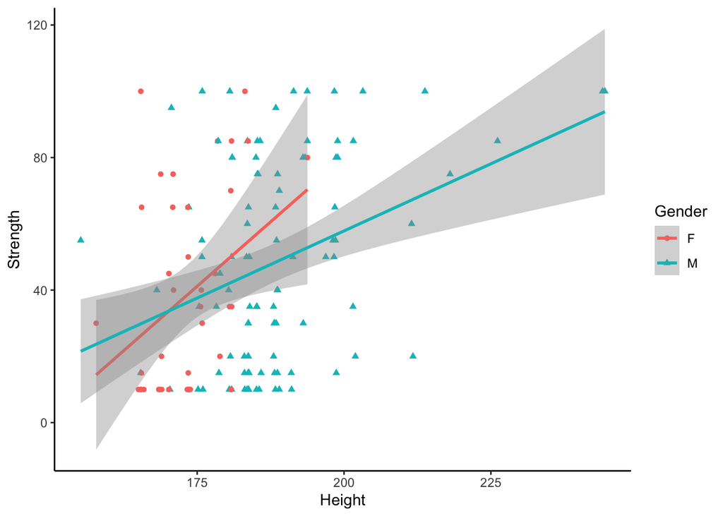

```r
heroes2 |>
  filter(Height < 250) |>
  ggplot(aes(x = Height, y = Strength, color = Gender, shape = Gender)) +
  geom_point() +
  geom_smooth(method = "lm") +
  theme_classic()
```

Now that we have a clearer scatter plot, let us take a look inside the code.

In the `aes()` section, we can see that I identify the color AND the shape with `Gender`. Usually one kinds of specification would work, however, sometimes the color might not be easily identifiable. Therefore, it is useful to add another features in this category to make your graph more readable.

- `geom_point()` is what we use to identify each data point as a point on the graph. Thus, creating the scatter plot.
- `geom_smooth()` is adding trend lines on the data. Here by using `method = "lm"` meaning that we use linear model, which keeps the line straight.
- `theme()` is the function to change the theme of the graph. I commonly use `theme_classic()`, `theme_light()`, or the default `theme_gray()`.

### box plot

### density plot

## Efficiency Tips for Data Processing

## Data Export

## Colclusion and Advanced Learning

## let’s draw flags!

[figure not shown]

```r
library(ggplot2)
library(dplyr)

lith <- data.frame(name=c("A","B","C") ,
                   value=c(4,4,4))

lith %>%
  ggplot(aes(x = name, y = value)) +
  geom_bar(stat = "summary", width = 1, fill = c("#BE3A34","#046A38","#FFB81C")) +
  coord_flip()+
  theme_void()
```

[figure not shown]

```r
latv <- data.frame(name=c("A","B","C") ,
                   value=c(4,4,4))

latv %>%
  ggplot(aes(x = name, y = value)) +
  geom_bar(stat = "identity", width = c(1.2, 0.9, 1.2), fill = c("#A4343A","#FFFFFF","#A4343A")) +
  coord_flip()+
  theme_void()
```

I am still a bit struggling with the width part. The flag looks okay but I don’t think this is the correct way to do it.

Now let’s try some with vertical lines.

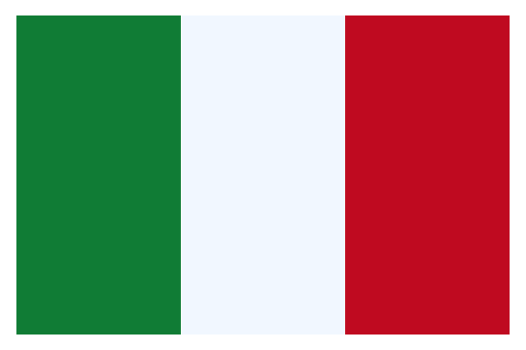

```r
ital <- data.frame(name=c("A","B","C") ,
                   value=4)

ital %>%
  ggplot(aes(x = name, y = value)) +
  geom_bar(stat = "identity", width = 1, fill = c("#008C45","#F4F9FF","#CD212A")) +
  theme_void()
```

Still struggling with the Icelandic flag. Stay tuned.

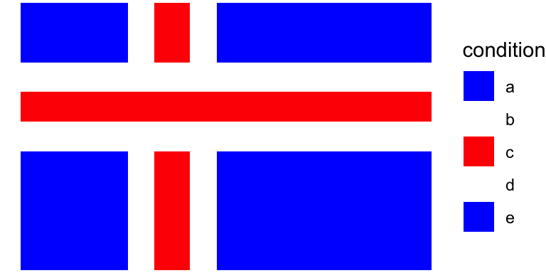

```r
specie <- c("A","B" ,"C","D","E","F","G","H","I")
condition <- c("a","b","c","d","d","c","d","c","d",
               "e","a","b","c","d","c","d" ,"b","c",
               "d","e","a","b","d","c","d","a" ,"b",
               "c","d","e","a","d","c","d","e", "a" ,
               "b","c","d","e","d" ,"c","d","d","e")
value <- c(6, 0.75, 1, 0.75, 3)
data <- data.frame(specie,condition,value)
ggplot(data, aes(fill=condition, y=value, x=specie)) +
  geom_bar(position="fill", stat="identity", width = 1)+
  scale_fill_manual(values=c("blue", "white", "red","white","blue")) +
  coord_flip() +
  theme_void()
```